# Data Analyst Professional Practical Exam Submission

**You can use any tool that you want to do your analysis and create visualizations. Use this template to write up your summary for submission.**

You can use any markdown formatting you wish. If you are not familiar with Markdown, read the [Markdown Guide](https://s3.amazonaws.com/talent-assets.datacamp.com/Markdown+Guide.pdf) before you start.

#### This project was completed in Nov, 2025.

## 📝 Task List

Your written report should include written text summaries and graphics of the following:

- **Data validation:**
  - Describe validation and cleaning steps for every column in the data
- **Exploratory Analysis:**
  - Include two different graphics showing single variables only to demonstrate the characteristics of data
  - Include at least one graphic showing two or more variables to represent the relationship between features
  - Describe your findings
- **Definition of a metric for the business to monitor**
  - How should the business use the metric to monitor the business problem
  - Can you estimate initial value(s) for the metric based on the current data
- **Final summary including recommendations that the business should undertake**

*Start writing report here..*

## ✅ When you have finished...

- Publish your Workspace using the option on the left
- Check the published version of your report:
  - Can you see everything you want us to grade?
  - Are all the graphics visible?
- Review the grading rubric. Have you included everything that will be graded?
- Head back to the [Certification Dashboard](https://app.datacamp.com/certification) to submit your practical exam report and record your presentation

# ---------------------------------------------------------------------------------------------------------------

# ---------------------------------------------------------------------------------------------------------------

# ---------------------------------------------------------------------------------------------------------------

## 📖 The Background

##### About Pens & Printers

*Pens and Printers* was founded in 1984 and provides high quality office products to large organizations. We are a trusted provider of everything from pens and notebooks to desk chairs and monitors. We don’t produce our own products but sell those made by other companies.

We have built long lasting relationships with our customers and they trust us to provide them with the best products for them. As the way in which consumers buy products is changing, our sales tactics have to change too. Launching a new product line is expensive and we need to make sure we are using the best techniques to sell the new product effectively. The best approach may vary for each new product so we need to learn quickly what works and what doesn't.

##### New Product Sales Methods

Six weeks ago we launched a new line of office stationery. Despite the world becoming increasingly digital, there is still demand for notebooks, pens and sticky notes. Our focus has been on selling products to enable our customers to be more creative, focused on tools for brainstorming. We have tested three different sales strategies for this, targeted email and phone calls, as well as combining the two.

- **Email:** Customers in this group received an email when the product line was launched, and a further email three weeks later. This required very little work for the team.
- **Call:** Customers in this group were called by a member of the sales team. On average, members of the team were on the phone for around thirty minutes per customer.
- **Email & call:** Customers in this group were first sent the product information email, then called a week later by the sales team to talk about their needs and how this new product may support their work. The email required little work from the team, the call was around ten minutes per customer.

## 💾 The Data

The sales rep has pulled some data from their sales tracking system for us. They haven't included numbers for how much time was spent on each customer, but there may be some other useful customer information in here.  
The data only relates to the new products sold. As there are multiple different products, the revenue will vary depending on which products were sold.  
The data hasn’t been validated, so make sure that you check it against all of the information in the table before you start your analysis.

| Column Name | Details |
| --- | --- |
| `week` | Week sale was made, counted as weeks since product launch |
| `sales_method` | Character, which of the three sales methods were used for that customer |
| `customer_id` | Character, unique identifier for the customer |
| `nb_sold` | Numeric, number of new products sold |
| `revenue` | Numeric, revenue from the sales, rounded to 2 decimal places. |
| `years_as_customer` | Numeric, number of years customer has been buying from us (company founded in 1984) |
| `nb_site_visits` | Numeric, number of times the customer has visited our website in the last 6 months |
| `state` | Character, location of the customer i.e. where orders are shipped |

# Objectives

### 📝 Task List

Your written report should include written text summaries and graphics of the following:

- **Data validation:**
  - Describe validation and cleaning steps for every column in the data
- **Exploratory Analysis:**
  - Include two different graphics showing single variables only to demonstrate the characteristics of data
  - Include at least one graphic showing two or more variables to represent the relationship between features
  - Describe your findings
- **Definition of a metric for the business to monitor**
  - How should the business use the metric to monitor the business problem
  - Can you estimate initial value(s) for the metric based on the current data
- **Final summary including recommendations that the business should undertake**

### 📧 From Sales Rep

In the emails between the sales & analytical teams, the former requested responses to the following.

- How many customers were there for each approach?
- What does the spread of the revenue look like overall? And for each method?
- Was there any difference in revenue over time for each of the methods?
- Based on the data, which method would you recommend we (the sales team) continue to use? Some of these methods take more time from the team so they may not be the best for us to use if the results are similar.
- We don't really know if there are other differences between the customers in each group, so anything you can tell us would be really helpful to give some context to what went well.

# Summary of Findings & Recommendations

These conclusions are broken down into five sections according to the tasks specifically requested by the sales rep.

### Analysis I

*How many customers were there for each approach?*

Of the 15,000 customers who have made purchases from the new product line in the last six weeks, about half of them only received an email, about a third only received a phone call, & about a sixth received both. In other words, for every six customers, generally, three of them were contacted via email, two via phone, & one via both.

### Analysis II

*What does the spread of the revenue look like overall? And for each method?*

Generally, revenue was smaller for most customers' orders which indicates a slight positive (right-tailed) skew that is not incredibly significant. The data spans values between about 32-240 in revenue. The median & mean revenue is about 90 & 94 respectively.

When split across sales methods, there are striking differences in the revenues from these sales.

- Most revenues from customers' orders in which the business contacted them via phone were the smallest across the whole revenue distribution by a significant & clear margin (between 32-90).
- Revenues from orders of customers who were contacted by email generally occupied the middle part of the overall revenue distribution (75-150).
- Revenues from orders of customers who were contacted by both methods generally accounted for the largest values across the overall revenue distribution (89-239).

### Analysis III

*Was there any difference in revenue over time for each of the methods?*

Over the last six weeks, all three sales methods saw a considerable increase in typical revenue on a per customer basis. These increases, the smallest & largest of which pertained to the "Email" & "Call" groups respectively, suggest that all three sales techniques became increasingly more effective over time in terms of generating revenue, particularly phone calls. This is supported even further by the fact that the number of customers contacted per week generally decreased over the last six weeks. More specifically, the typical weekly revenue across each sales method changed as follows.

- For customers contacted via phone only, the typical weekly revenue increased by about 89% over the six-week time period.
- For customers contacted via email only, the typical weekly revenue increased by about 49% over the six-week time period.
- For customers contacted via email & phone, the typical weekly revenue increased by about 77% over the six-week time period.

Multiple factors could be at play regarding these trends such as the quality of advertising, the number of customers who were contacted, or other variables in the dataset.

### Analysis IV

*Based on the data, which method would you recommend we (the sales team) continue to use? Some of these methods take more time from the team so they may not be the best for us to use if the results are similar.*

##### Establishing a metric

A metric was created to help quantify the effectiveness of each sales method based on the total revenue obtained & the effort/time typically utilized advertising to a customer. The times, two of which are provided by the sales team directly, are as follows.

- *Phone Call only*: Team members were on the phone for around 30 minutes on average per customer.
- *Email only*: It is estimated that constructing & sending an email took no more than three minutes on average.
- *Email + Call*: Customers were sent an email & called about a week later. These phone calls were around ten minutes on average per customer.

With these estimates, the ratio of the typical revenue per customer & the typical amount of time spent on each customer can be obtained for each sales method. For example, the typical revenue per customer in the "Email" group divided by the typical time spent advertising to a customer in this group (about three minutes) gives an estimate of the typical revenue obtained per minute of advertising via email.

Generally, the value of this metric increased over the last six weeks. In the most recent week of data, the three sales methods have the following typical revenue efficiencies.

- *Phone Call only*: About \$132 per hour.
- *Email only*: About \$2,597 per hour.
- *Email + Call*: About \$1,047 per hour.

Not only can this metric assess how the relative effectiveness of each sales method has evolved over the last six weeks, but it can also be used to project revenue efficiencies in the near future & provide recommendations regarding how the sales team's time spent advertising can be optimized.

##### Recommendations

In contextualizing the findings from the revenue efficiency metric with those of previous analyses, it is clear that only calling customers was the least productive sales strategy by far in terms of both outright revenue as well as revenue efficiency. Ideally, this technique, given how much less profitable it has been in comparison to the other two methods, should be utilized at a minimum; however, this is not to say that talking to customers directly over the phone does not have some value. Moreover, with how much time the sales team typically spends on these phone calls—about 30 minutes per customer, which is the most of any of the three methods—it would be more productive for them to spend most of their time emailing customers & occasionally calling some people about a week after emailing them.

Utilizing both sales techniques resulted in the most revenue per customer, but this method hasn't been quite as efficient as only emailing customers. Therefore, emailing customers should continue to be the primary sales method, which hasn't been the case in the most recent two weeks.

- In summary, an optimal strategy moving forward would involve mostly emailing customers & occasionally calling some people about a week after emailing them; the "Email" & "Email + Call" sales methods. Calling people who have not been emailed—the "Call" method—should be used at a minimum.

With this information in mind, it would be useful for the sales team to have a more defined plan as to how to optimize their time across the three sales methods. Since emails have the greatest revenue efficiency per customer & they require the least amount of time of the three sales methods, the revenue would theoretically be maximized if all of the sales team's time was allotted to this method alone; however, having some diversity in advertising approaches is more ideal to help keep the business competitive, relevant, & flexible.

As such, the balance between the amount of time spent on each sales method depends on how much the company values revenue versus diversity in their advertising approaches. A few examples were created (see the **Analysis IV** section) that lay out estimates of revenue & other quantities based on how much of an employee's time per week is spent advertising across each of the three sales methods. They all follow the same general strategy discussed previously—little time is spent only phoning customers, & most is spent sending emails out. Although relying more on emails alone will likely yield more revenue, these examples serve to provide an illustration of how the sales team can fiddle with the time they allot to each sales method to obtain a desirable (theoretical) revenue.

### Analysis V

*We don't really know if there are other differences between the customers in each group, so anything you can tell us would be really helpful to give some context to what went well.*

Additional variables were analyzed according to the sales method utilized to contact customers. They included the number of years a customer has made purchases, the number of new products that they have bought, & their state of residence. Of these three variables, only the number of products purchased by customers appeared to have a meaningful relationship with the sales methods by which customers were contacted.

- More specifically, customers who were contacted via email *&* phone typically bought two more products (in quantity) than a customer who was contacted via email *or* phone.

```python
#Import modules
import numpy as np
import pandas as pd

import matplotlib.pyplot as plt
import seaborn as sns

from IPython.display import IFrame
```

```python
# Display the PDF w/Project instructions
IFrame("Project Instructions.pdf", width=700, height=400)
```

[interactive chart not shown]

### Importing, Preprocessing, Exploratory Data Analysis

To begin, the data needs to be imported & inspected to determine if any preprocessing is required prior to analysis.

```python
#Import the data
orig_df = pd.read_csv("product_sales.csv")

#Inspect the data
display(orig_df.head(5))
display(orig_df.info())
```

|  | week | sales_method | customer_id | nb_sold | revenue | years_as_customer | nb_site_visits | state |
| --- | --- | --- | --- | --- | --- | --- | --- | --- |
| 0 | 2 | Email | 2e72d641-95ac-497b-bbf8-4861764a7097 | 10 | NaN | 0 | 24 | Arizona |
| 1 | 6 | Email + Call | 3998a98d-70f5-44f7-942e-789bb8ad2fe7 | 15 | 225.47 | 1 | 28 | Kansas |
| 2 | 5 | Call | d1de9884-8059-4065-b10f-86eef57e4a44 | 11 | 52.55 | 6 | 26 | Wisconsin |
| 3 | 4 | Email | 78aa75a4-ffeb-4817-b1d0-2f030783c5d7 | 11 | NaN | 3 | 25 | Indiana |
| 4 | 3 | Email | 10e6d446-10a5-42e5-8210-1b5438f70922 | 9 | 90.49 | 0 | 28 | Illinois |

```
<class 'pandas.core.frame.DataFrame'>
RangeIndex: 15000 entries, 0 to 14999
Data columns (total 8 columns):
 #   Column             Non-Null Count  Dtype
---  ------             --------------  -----
 0   week               15000 non-null  int64
 1   sales_method       15000 non-null  object
 2   customer_id        15000 non-null  object
 3   nb_sold            15000 non-null  int64
 4   revenue            13926 non-null  float64
 5   years_as_customer  15000 non-null  int64
 6   nb_site_visits     15000 non-null  int64
 7   state              15000 non-null  object
dtypes: float64(1), int64(4), object(3)
memory usage: 937.6+ KB
```

```
None
```

There are 15,000 observations & eight variables in the original dataset. One variable ('revenue') has missing values (1,074). The data types for each variable seem appropriate. Next, the values in each variable can be perused to look for strange or unusual values that may point to typos, entry errors, or some other inconsistency.

```python
#Inspect values across columns
#display(orig_df['state'].value_counts(dropna=False).sort_values())
#display(orig_df['state'].nunique())

#Inspect data points w/missing 'revenue' values
display(orig_df[orig_df.revenue.isna()]['sales_method'].value_counts(dropna=False))
```

```
sales_method
Email           541
Email + Call    346
Call            181
em + call         3
email             3
Name: count, dtype: int64
```

In summary, the variables 'sales_method,' 'revenue,' & 'years_as_customer' need some preprocessing done.

```python
#Make a copy of the data to avoid modifying the original
df = orig_df.copy()

#Clean the 'sales_method' variable. Alter some values
df['sales_method'] = df['sales_method'].replace({'em + call':'Email + Call', 'email':'Email'})

#Clean the 'years_as_customer' variable. Truncate some values
df['years_as_customer'] = df['years_as_customer'].replace({47:42, 63:42})


#Evaluate the 'revenue' variable to determine how to handle the missing values.
    #Filter for data points with missing 'revenue's, inspect other variables to search for potential relationships
missing_df = orig_df[orig_df['revenue'].isna()]
display(orig_df['week'].value_counts(dropna=False).sort_index())
display(missing_df['week'].value_counts(dropna=False).sort_index())
```

```
week
1    3721
2    2491
3    2411
4    2575
5    2574
6    1228
Name: count, dtype: int64
```

```
week
1    224
2    168
3    154
4    188
5    208
6    132
Name: count, dtype: int64
```

The values of each variable were analyzed with respect to the data points with missing 'revenue' values to search for a potential relationship. For example, it could have been possible that most or all of the missing data corresponded to orders shipped to customers in a certain state or sales data from a specific week. However, there was no clear pattern or value(s) that corresponded to a majority of the missing 'revenue' values. As such, another method needs to be used to determine how the missing values should be handled.

By plotting the distribution of a numerical variable, it can be used to determine what metrics may be more appropriate for imputing missing values. If a variable is distributed normally (bell-curved), then the mean can be used for imputation; however, if the data is skewed significantly enough, then the mean no longer becomes suitable. Instead, the median would be a more viable statistic for imputation.

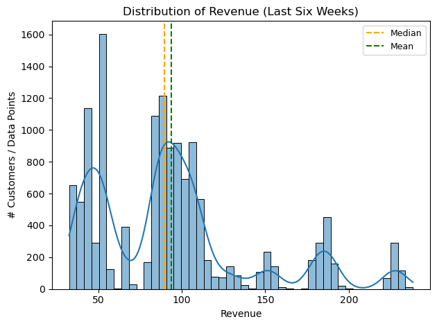

```python
#Evaluate the 'revenue' variable to determine how to handle the missing values. Plot the distribution
ax1 = sns.histplot(data=orig_df, x='revenue', kde=True)
#add the median, mean
ax1.axvline(x=orig_df['revenue'].median(), color='orange', linestyle='--', label='Median')
ax1.axvline(x=orig_df['revenue'].mean(), color='green', linestyle='--', label='Mean')
#edit plot details
plt.title('Distribution of Revenue (Last Six Weeks)')
plt.xlabel('Revenue')
plt.ylabel('# Customers / Data Points')
plt.legend(loc='upper right', fontsize=9)
plt.tight_layout();
```

The histogram above illustrates the distribution of the 'revenue' variable. There are about 13,900 data points making up this plot; ~1,100 missing values.  
The distribution appears to be multimodal with a sizable skew to the right. Given that the distribution is far from normal, the median would be more appropriate to impute the missing 'revenue' values with rather than the mean.

- For reference, the median 'revenue' value is 89.5, whereas the average 'revenue' is about 93.9. The former is already at two decimal places so no rounding is necessary.

```python
#Impute missing 'revenue' values with the median
df['revenue'] = df['revenue'].fillna(orig_df['revenue'].median())

#Review the updated dataset
display(df.info())
```

```
<class 'pandas.core.frame.DataFrame'>
RangeIndex: 15000 entries, 0 to 14999
Data columns (total 8 columns):
 #   Column             Non-Null Count  Dtype
---  ------             --------------  -----
 0   week               15000 non-null  int64
 1   sales_method       15000 non-null  object
 2   customer_id        15000 non-null  object
 3   nb_sold            15000 non-null  int64
 4   revenue            15000 non-null  float64
 5   years_as_customer  15000 non-null  int64
 6   nb_site_visits     15000 non-null  int64
 7   state              15000 non-null  object
dtypes: float64(1), int64(4), object(3)
memory usage: 937.6+ KB
```

```
None
```

With preprocessing complete, analyses can be performed. Five sections were built to directly answer each of the inquiries listed by the sales team, which can be referenced in the **Objectives** section.

# Analysis I

*How many customers were there for each approach?*

To do so, calculate the number of customers for each 'sales_method' since the new office stationery products were launched six weeks prior. Recall that there are three such approaches. Moreover, every data point in the dataset corresponds to a unique customer, so the 'customer_id' variable doesn't need to be included in the grouping function(s).

|  | sales_method | # customers | % total customers |
| --- | --- | --- | --- |
| 0 | Call | 4962 | 33.08 |
| 1 | Email | 7466 | 49.77 |
| 2 | Email + Call | 2572 | 17.15 |

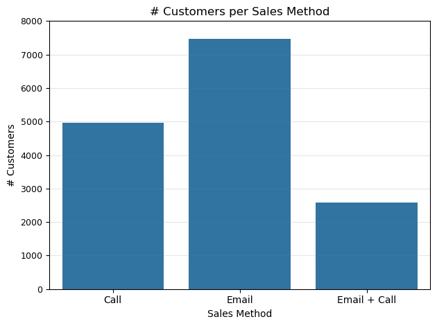

```python
#Calculate the # customers per 'sales_method'
num_method = df.groupby('sales_method').size().reset_index().rename(columns={0:'# customers'})
#Add a variable indicating the % of total customers per 'sales_method'
num_method['% total customers'] = np.round(100*num_method['# customers']/num_method['# customers'].sum(), 2)
display(num_method)

#Visualize the data
ax1 = sns.barplot(data=num_method, x='sales_method', y='# customers')
#edit plot details
plt.title('# Customers per Sales Method')
plt.xlabel('Sales Method')
plt.ylabel('# Customers')
plt.yticks(fontsize=9)
plt.ylim(0,8000)
plt.grid(axis='y',alpha=0.2,color='gray')
plt.tight_layout();
```

The figure above illustrates the number of customers who have made purchases over the last six weeks based on the sales method used to contact them. There are 15,000 total customers making up this plot.

It is logical that **emails** were the most common sales strategy given their ease of communication between business & customer. Over the last six weeks, almost half of *Pens & Printers'* sales in terms of total orders have come from emails only--about 7,466 customers. Although this method may be the most time-efficient, this figure alone is unable to quantify its effectiveness relative to the other two methods.

Speaking of the other methods, customers who received **phone calls** regarding the company's new products who also made at least one purchase were the second most popular group. In total, this sales method accounted for about a third of the customers who have made purchases in the last six weeks--about 4,962 customers.

- Given that making phone calls to customers required significantly more time & effort from the business, the fact that this group only resulted in about 2,500 less customers making purchases than the "Email" group could signify that phone calls, on average, were noticeably more effective in terms of people making purchases.
  - Recall that typically, members of the sales team were on the phone with customers for about 30 minutes each. If it takes no more than five minutes to construct & send an email, then an employee could contact at least six times as many customers via email than a phone call. In this case, the number of customers in the "Email" group was only about 50 percent larger than the number of customers in the "Call" group. Therefore, this suggests that a single phone call to a customer is approximately equally as effective as an email to three customers.
  - Work & analysis specifically pertaining to the typical effectiveness of each sales method can be seen in later sections.

The group of customers who made purchases that received **both an email & a phone call** accounted for the smallest split of the three sales methods--2,572 customers, or about half the number of customers who received only a phone call. Since multiple techniques are being utilized, it seems logical that this method could be more effective than the prior two.

- Recall that on average, calls to these customers were about ten minutes per. If the email took no more than five minutes, this process would require about 15 in total which is about half the time generally spent on customers in the "Call" group. Since there are about half as many customers in the "Email + Call" group than the "Call" group, it suggests that these two methods were generally equally as effective.
- On another note, note that calls to this group of customers lasted about a third of the time than conversations with customers from the "Call" group. This could potentially indicate that customers were more easily encouraged to make a purchase from the phone call after they had already received an email because the lengths of the phone calls were so much shorter on average.

**In summary**, of the 15,000 customers who have made purchases from the new product line in the last six weeks, about half of them only received an email, about a third only received a phone call, & about a sixth received both. In other words, for every six customers, generally, three of them were contacted via email, two via phone, & one via both.

# Analysis II

*What does the spread of the revenue look like overall? And for each method?*

Similarly to the Exploratory Data Analysis (EDA) section, a histogram can be used to visualize the revenue overall. For each sales method, box plots can be used. It would be useful to compare the distribution of revenue for each group to each other as well as to the overall distribution.

- Recall that the units of the 'revenue' variable are not indicated directly, but they are presumed to be US dollars ($).
- Recall that 1,074 data points did not have an original revenue value. These missing values were imputed using the median revenue (89.5).

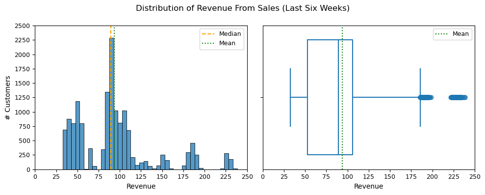

```python
#Create a subplot figure
fig, axes = plt.subplots(ncols=2, figsize=(10,4))

#Visualize the 'revenue' variable
#HISTOGRAM
ax1 = sns.histplot(data=df, x='revenue', binwidth=5, ax=axes[0])
#Add the median, mean revenue
ax1.axvline(x=df['revenue'].median(), color='orange', linestyle='--', label='Median')
ax1.axvline(x=df['revenue'].mean(), color='green', linestyle=':', label='Mean')
#BOXPLOT
ax2 = sns.boxplot(data=df, x='revenue', fill=False, ax=axes[1])
#Add the mean revenue
ax2.axvline(x=df['revenue'].mean(), color='green', linestyle=':', label='Mean')

#edit plot details
fig.suptitle('Distribution of Revenue From Sales (Last Six Weeks)')
for v in [0,1]:
    plt.sca(axes[v])
    plt.xlabel('Revenue')
    plt.xticks(fontsize=9, ticks=range(0,251,25))
    if v == 0:
        plt.ylabel('# Customers')
        plt.yticks(fontsize=9, ticks=range(0,2501,250))
    plt.legend(fontsize=9, loc='upper right')
    plt.tight_layout();
```

The plots above illustrate the distribution of the revenue of sales of new products from the past six weeks. There are 15,000 data points that make up these figures. The mean & median revenue are illustrated in the two plots via the colored, dotted & dashed lines respectively.

Generally, revenue was smaller for most customers' orders indicating a slight positive (right-tailed) skew, but this skew is not incredibly significant. The data spans values between about 32-240 in revenue. While there are no small outliers, there are hundreds of large outliers with a revenue of about 185 or higher. The median & mean revenue is about 89.5 & 93.6 respectively.

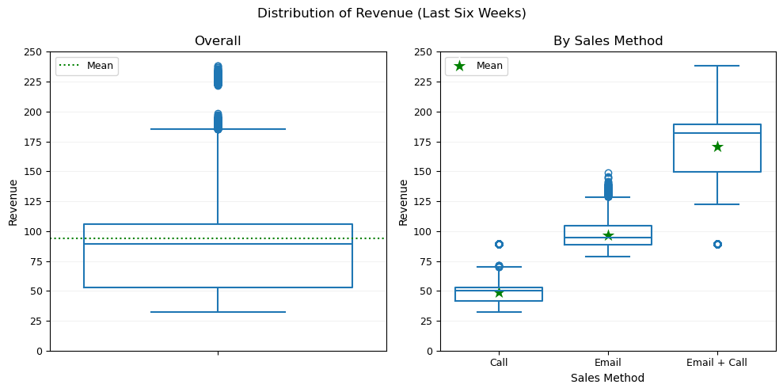

```python
#Obtain mean 'revenue' for each 'sales_method'
avg_rev_methods = df.groupby('sales_method')['revenue'].mean().reset_index().rename(
    columns={'revenue':'avg revenue'}).sort_values('sales_method')

#Create a subplot figure
fig, axes = plt.subplots(ncols=2, figsize=(10,5))
#Visualize the 'revenue' variable
ax1 = sns.boxplot(data=df, y='revenue', fill=False, ax=axes[0])
#Add the mean revenue
ax1.axhline(y=df['revenue'].mean(), color='green', linestyle=':', label='Mean')

#Visualize the 'revenue' variable across 'sales_method'
ax2 = sns.boxplot(data=df, x='sales_method', y='revenue', order=['Call','Email','Email + Call'], fill=False, ax=axes[1])
#Append the mean revenue for each method
sns.scatterplot(data=avg_rev_methods, x='sales_method', y='avg revenue', marker='*', color='green', label='Mean', s=250,
                ax=axes[1])

#edit plot details
fig.suptitle('Distribution of Revenue (Last Six Weeks)')
for k, v in {'Overall':[0],
            'By Sales Method':[1]}.items():
    plt.sca(axes[v[0]])
    plt.title(k)
    if v[0] == 1:
        plt.xlabel('Sales Method')
    plt.xticks(fontsize=9)
    plt.ylabel('Revenue')
    plt.yticks(ticks=range(0,251,25), fontsize=9)
    plt.legend(loc='upper left', fontsize=9)
    plt.grid(axis='y',alpha=0.1,color='gray')
    plt.tight_layout();
```

The figure above visualizes the distribution of revenue of sales of new products over the last six weeks based on the sales method utilized. This plot is built from 15,000 data points. The green stars indicate the average revenue for each sales strategy. Recall that about half of the data points correspond to the "Email" group, about one third are in the "Call" group, & about one sixth are in the "Email + Call" group. Nonetheless, each group has a representative number of observations.

Across the three sales methods, the revenue splits are quite distinctive.

##### Phone Call only

Revenue from orders in which the sales team contacted customers via phone accounted for most of the values at the bottom of the overall revenue distribution. More specifically, revenue from such customers is between about 32-90. The mean & median revenues of these customers' orders are slightly greater than half of those across the overall revenue distribution. More specifically, the average & median revenue of this group is about 49 & 50 respectively.  
There is some slight overlap with the other two groups, particularly the "Email" group; however, most revenues of the "Call" group are less than those of the other two groups.

##### Email & phone call

Revenue from orders in which the sales team contacted customers via email & phone accounted for most of the values near the top of the overall revenue distribution. More specifically, revenue from such customers is between about 89-239. The mean & median revenues of these customers' orders are nearly double those of the overall revenue distribution. More specifically, the average & median revenue of this group is about 171 & 182 respectively.  
There is some slight overlap with the other two groups, but most revenues of the "Email + Call" group are greater than those of the other two groups, particularly the "Call" group.

- Recall that about 1,100 data points had their 'revenue' value imputed with the median value (89.5). This value is the one outlier displayed in the box plot for the "Email + Call" group. Excluding these imputed venues, the next smallest value is about 122 which is considerably larger than the maximum revenue from the "Call" group.

**In summary**, the revenues collected in the sales data span about 200 units. There is a slight positive skew--most are smaller (< 90) than than they are large (> 90). When split across sales methods, there are striking differences in the revenues from these sales.

- Most revenues from customers' orders in which the business contacted them via **phone** were the smallest across the whole revenue distribution by a significant & clear margin (between 32-90).
- Revenues from orders of customers who were contacted by **email** generally occupied the middle part of the overall revenue distribution (75-150).
- Revenues from orders of customers who were contacted by **both methods** generally accounted for the largest values across the overall revenue distribution (89-239).

# Analysis III

*Was there any difference in revenue over time for each of the methods?*

When illustrating data that is time dependent, a line plot is usually appropriate. Since previous dates are being referenced, it would be more fitting to place the most recent data on the right side of such a figure, whereas the older data can go on the left side. This alignment would illustrate how the data changed over time in a chronological manner rather than going backwards.

To visualize revenue over the last six weeks, various metrics can be used including total revenue per week, average revenues, or median values. Since there are different numbers of data points corresponding to each of the three sales methods as well as each of the six last weeks, a statistic that can normalize for these uneven frequencies (i.e. average, median) may be more insightful in determining which strategy is most worth the sales team's time & effort.

- Given that customers who were contacted only via email account for about half of the data, their revenue splits will likely be inflated relative to those of the other two groups because this group simply has more data points & not necessarily because of better performance.
- Ultimately, the sales team has expressed an interest in determining which sales method is the most effective use of their time. As such, the average/median would be more indicative of each strategy's effectiveness because they quantify typical values better than a sum. Moreover, to counter the influence of outliers & uncommon data points, the median would be more appropriate given that it is more robust to such values than the mean.
- Recall that each data point corresponds to a specific customer, when they made a purchase, how much revenue was generated from those sales, etc. As such, obtaining the median revenue per week will quantify the typical revenue obtained per customer on a weekly basis.

On another note, it is worth pointing out that about 1,100 data points had their 'revenue' imputed with the overall median value across the entire dataset which was 89.5.

To start, it could be worth investigating how the sales team's behavior regarding contacting customers has evolved over the last six weeks.

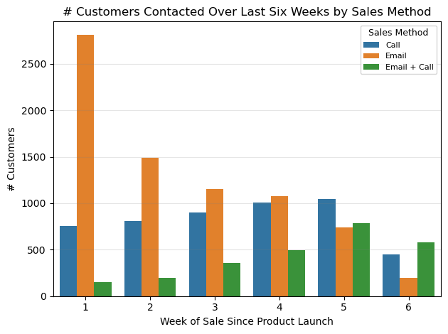

```python
#Visualize the # customers based on 'sales_method' over last 6 weeks
ax1 = sns.countplot(data=df, x='week', hue='sales_method', hue_order=['Call','Email','Email + Call'])
#edit plot details
plt.title('# Customers Contacted Over Last Six Weeks by Sales Method')
plt.xlabel('Week of Sale Since Product Launch')
plt.ylabel('# Customers')
plt.legend(title='Sales Method', title_fontsize=9, fontsize=8, loc='upper right')
plt.grid(axis='y',alpha=0.2,color='gray')
plt.tight_layout();
```

The bar plot above illustrates the number of customers who have been contacted & made purchases over the last six weeks based on the sales method in which they were contacted by the sales team. 15,000 data points make up this visual. Recall that about half of these customers were contacted via email, about one-third via phone, & about one-sixth via email & phone. Note that the number of data points recorded in the most recent week (week six) is about half the number (or less) in any other week.

In the first week of the launch of the new line of products, a significant majority of customers received only an email; however, the sales team contacted more than 1,000 additional people in this first week than in any other.  
Over the next four weeks (weeks two through five), the customers contacted by email decreased considerably. On the other hand, the number of customers contacted by phone or by both phone & email increased over each of these four weeks, particularly the latter sales method.  
In the last & most recent week of data, where considerably fewer customers were contacted than in any other week, most customers were contacted by both email & phone. Email (without the call) was the least common technique.

This graphic helps illustrate how the sales team's usage of the three sales techniques has evolved over the past six weeks. With this context, it also might be useful to first create a figure that illustrates the data across the entire revenue distribution prior to segmenting it by sales method, similarly to **Analysis II**.

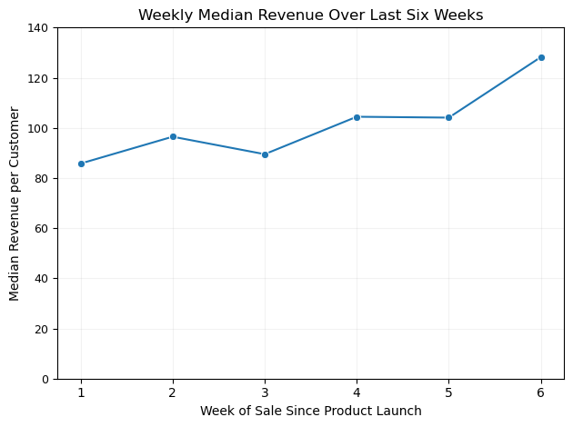

```python
#Calculate median 'revenue' per 'week' regardless of 'sales_method'
med_rev_wk = df.groupby('week')['revenue'].median().reset_index()

#Visualize the median 'revenue' per 'week'
ax1 = sns.lineplot(data=med_rev_wk, x='week', y='revenue', marker='o')
#edit plot details
plt.title('Weekly Median Revenue Over Last Six Weeks')
plt.xlabel('Week of Sale Since Product Launch')
plt.ylabel('Median Revenue per Customer')
plt.yticks(ticks=range(0,141,20), fontsize=9)
plt.grid(axis='both',alpha=0.1,color='gray')
plt.tight_layout();
```

The figure above quantifies the median revenue obtained per customer over the last six weeks independent of the sales method used to contact them. Recall that *Pens & Printers* launched a new line of office stationery about six weeks ago, so this plot helps illustrate the typical revenue obtained per customer on a weekly basis since these new products were made available. 15,000 customers made up this visualization. Although it is not specified, it is assumed that the revenue variable is in units of US dollars ($).

Over the last six weeks, this figure indicates that the revenue obtained per customer gradually increased on a weekly basis. Customers seemed to have become more enamored with the products despite fewer of them being contacted as time went on. The most logical explanation for this would be that the sales team's selling tactics became more effective over time.  
Recall that in the most previous plot, it was observed that generally, the sales team lessened the number of emails they sent out & increased the number of phone calls to customers. Also, the number of people they reached out to via both methods also increased over the first five weeks. Given this, it is reasonable to hypothesize that over time, the lessening of their reliance on mostly communicating only via email resulted in a meaningful change in terms of revenue & therein the interest levels of customers in the company's products. In other words, the evolution of how the three sales methods were used over time meaningfully contributed to the increasing weekly revenue trends seen in the plot above. More specifically, the decline in the size of the "Email"-customer group & the increase in the sizes of the "Call" & "Email & Call"-customer groups were effective in the positive, weekly revenue trends seen above.

By looking at the revenue generated from each sales method individually, such a claim can be quantified more directly.

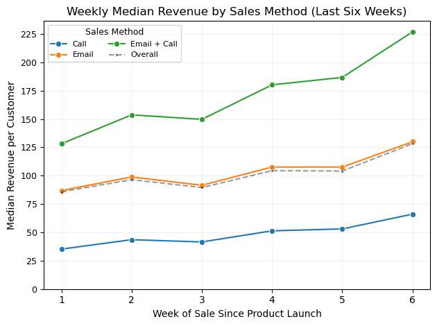

```python
#Calculate median 'revenue' per 'week' by 'sales_method'
med_rev_wk_method = df.groupby(['week','sales_method'])['revenue'].median().reset_index().rename(
                        columns={'revenue':'med_rev'})

#Visualize the median 'revenue' per 'week' by 'sales_method'
ax1 = sns.lineplot(data=med_rev_wk_method, x='week', y='med_rev', hue='sales_method', hue_order=['Call','Email','Email + Call'],
                   marker='o')
#Append the total median, weekly 'revenue' trend for comparison
ax1 = sns.lineplot(data=med_rev_wk, x='week', y='revenue', marker='.', linestyle='--', color='black', alpha=0.4,
                   label='Overall')
#edit plot details
plt.title('Weekly Median Revenue by Sales Method (Last Six Weeks)')
plt.xlabel('Week of Sale Since Product Launch')
plt.ylabel('Median Revenue per Customer')
plt.yticks(ticks=range(0,226,25), fontsize=9)
plt.legend(loc='upper left', title='Sales Method', title_fontsize=9, fontsize=8, ncols=2)
plt.grid(axis='both',alpha=0.1,color='gray')
plt.tight_layout();
```

The illustration above visualizes the median weekly revenue streams over the last six weeks based on how customers were contacted by the sales team. The black, dashed line serves as comparison between the weekly revenue splits & the overall revenue stream. 15,000 data points make up this figure. Although it is not specified, it is assumed that the revenue is in units of US dollars ($).

- Given that emails are considerably less time consuming for the sales team than talking to customers over the phone, the fact that the typical revenue from customers contacted via email is so noticeably greater than that of customers contacted via phone indicates that between these two methods, the sales team's time is better spent advertising via email. Of course, this isn't to say that they should only use email as a sales strategy, but given that it is less time consuming & more profitable than (only) phoning customers, they should prioritize this technique over (only) calling customers, which has not been the case in the last two weeks.

Between the first week of the launch & the most recent week of data, the typical revenue obtained per customer increased by about 50-90 percent across each of the three sales methods. More specifically, this increase was

- about 89% for customers contacted via phone only,
- about 49% for customers contacted via email only, &
- about 77% for customers contacted via both.

Given these percentage changes in typical revenue, it appears that the effectiveness of phone calls seems to have increased more than that of emails over the last six weeks. Recall that in recent weeks, the number of customers contacted via phone generally increased on a weekly basis, whereas the number of people contacted via email decreased considerably.  
In incorporating the revenue evolution of the "Email + Call" group, it appears that the effectiveness of phoning a customer is generally greater than that of emailing them. Recall that the phone calls to customers who were also emailed were about 10 minutes, whereas those to customers who did not receive an email lasted about 30 minutes on average. Despite this sizable difference, the typical weekly increase in revenue for the "Call" group was only about 12% greater than that of the "Email + Call" group. If phone calls to customers in the latter group were a bit more thorough &/or more extensive, then perhaps they could yield even greater revenue totals. At the same time, however, such customers may not need as much time to be persuaded because they already have prior information & context from the email they received beforehand.

**In summary**, all three sales methods saw a considerable increase in typical revenue obtained per customer over the last six weeks. These increases, the smallest & largest of which pertained to the "Email" & "Call" groups respectively, suggest that all three sales techniques became increasingly more effective over time, particularly phone calls. Multiple factors could be at play regarding these trends such as the quality of advertising or the number of customers who were contacted.

# Analysis IV

*Based on the data, which method would you recommend we continue to use? Some of these methods take more time from the team so they may not be the best for us to use if the results are similar.*

Thus far, it has been determined that generally, the "Email + Call" sales strategy has yielded the most revenue per customer, whereas only phoning someone has typically produced the least. However, with only a limited number of hours available each week to advertise, it's important that *Pens & Printers* use their time as effectively as possible. Rather than committing all of the sales team's resources to a single sales technique, a combination of the three methods might yield the most dividends. The obvious question then becomes, how can the team spend their time to optimize sales revenue?

To evaluate this question, some new metrics can be established using the data & information provided. One such metric could quantify the effectiveness or efficiency of a sales method based on the total revenue obtained & the effort/time/cost utilized on a customer.  
Recall that the sales team estimated the amount of time they spend talking to customers on the phone when utilizing the "Call" & "Email + Call" sales techniques. When they only called a customer, the phone call lasted about 30 minutes on average. When they sent an email a week before calling a customer, the phone call lasted about ten minutes per customer. Say that writing & sending an email to a customer takes no longer than three minutes. If so, the typical amount of time per sales method follows as: "Email" (~ 3 minutes), "Email + Call" (~ 13 minutes across one week), & "Call" (~ 30 minutes).

- This in conjunction with the results from **Analysis III** emphasizes how only calling customers (the "Call" method) is the least effective strategy in terms of accruing revenue.

With the usual amount of time per sales method now defined, the relative revenue efficiency per advertisement/customer can be calculated. To do so, the ratio of the typical revenue per customer & the typical amount of time spent on each customer can be obtained for each sales method. For example, the typical revenue per customer in the "Email" group divided by the typical time spent advertising to a customer in this group--about three minutes--gives an estimate of the typical revenue generated per minute. Moreover, this metric can be converted to other time units (i.e. hours, weeks) to generalize.

- As done previously, the median revenue can be used rather than the mean for each sales method since this statistic provides a better assessment of the "typical" revenue. The weekly, median revenues per sales method can be retrieved via the `med_rev_wk_method` variable.
- Moreover, this metric can be evaluated over time, similarly to **Analysis III**, to see how it has evolved since the new line of products was launched six weeks ago.
- Although the units of the 'revenue' were not provided, they are presumed to be US dollars ($).

This metric can be of assistance when evaluating which sales method(s), or some combination of them, yielded the greatest revenue based on the amount of time spent advertising. By using the most recent data, it can provide an assessment of how the company is currently performing in terms of revenue efficiency & how the strategy of the sales team could be altered to improve this performance.

```python
#Define typical time spent per customer by 'sales_method' (minutes)
avg_time_call = 30
avg_time_em = 3
avg_time_em_call = 13

#Calculate revenue efficiency on a weekly basis per 'sales_method'
rev_eff_wk_method = med_rev_wk_method.reset_index(drop=True).copy()
for i in rev_eff_wk_method.index:
    #CALL group
    if rev_eff_wk_method.loc[i,'sales_method'] == 'Call':
        #Revenue efficiency per minute
        rev_eff_wk_method.loc[i,'rev_eff ($/min)'] = np.round(rev_eff_wk_method.loc[i,'med_rev'] / avg_time_call, 3)
        #Revenue efficiency per hour
        rev_eff_wk_method.loc[i,'rev_eff ($/hr)'] = np.round(60*rev_eff_wk_method.loc[i,'med_rev'] / avg_time_call, 3)

    #EMAIL group
    elif rev_eff_wk_method.loc[i,'sales_method'] == 'Email':
        #Revenue efficiency per minute
        rev_eff_wk_method.loc[i,'rev_eff ($/min)'] = np.round(rev_eff_wk_method.loc[i,'med_rev'] / avg_time_em, 3)
        #Revenue efficiency per hour
        rev_eff_wk_method.loc[i,'rev_eff ($/hr)'] = np.round(60*rev_eff_wk_method.loc[i,'med_rev'] / avg_time_em, 3)

    #EMAIL+CALL group
    else:
        #Revenue efficiency per minute
        rev_eff_wk_method.loc[i,'rev_eff ($/min)'] = np.round(rev_eff_wk_method.loc[i,'med_rev'] / avg_time_em_call, 3)
        #Revenue efficiency per hour
        rev_eff_wk_method.loc[i,'rev_eff ($/hr)'] = np.round(60*rev_eff_wk_method.loc[i,'med_rev'] / avg_time_em_call, 3)
```

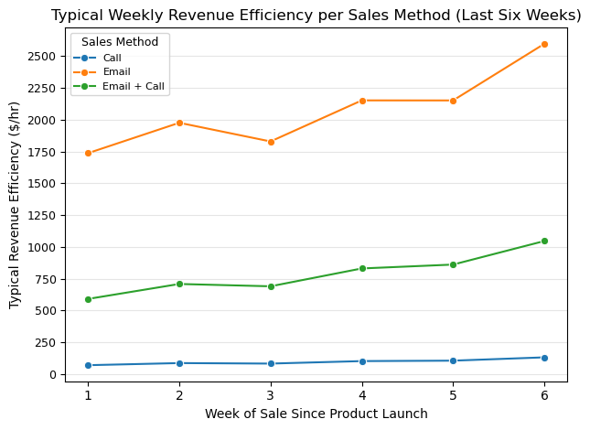

```python
#Visualize the revenue-efficiency metric
ax1 = sns.lineplot(data=rev_eff_wk_method, x='week', y='rev_eff ($/hr)', hue='sales_method',
                   hue_order=['Call','Email','Email + Call'], marker='o')
#edit plot details
plt.title('Typical Weekly Revenue Efficiency per Sales Method (Last Six Weeks)')
plt.xlabel('Week of Sale Since Product Launch')
plt.ylabel('Typical Revenue Efficiency ($/hr)')
plt.yticks(ticks=range(0,2501,250), fontsize=9)
plt.legend(title='Sales Method', title_fontsize=9, fontsize=8)
plt.grid(axis='y',alpha=0.2,color='gray')
plt.tight_layout();
```

The figure above quantifies the typical weekly revenue efficiency that quantifies the usual revenue obtained per customer according to the sales method used. The data spans the last six weeks--since the launch of the new line of office stationery. The efficiency metric measures the typical weekly revenue obtained per customer based on how much time was usually spent advertising to said customer according to the sales method used. This metric is in units of US dollars per hour. The plot was built from 15,000 data points.  
Recall that about half of the data points correspond to customers who were contacted via email, whereas about one-third of the customers were contacted via phone, & about one-sixth were contacted via both methods. Note that each sales method took the sales team differing amounts of time which are listed below.

- *Phone Call only*: Team members were on the phone for around 30 minutes on average per customer.
- *Email only*: It is estimated that constructing & sending an email took no more than three minutes on average.
- *Email + Call*: Customers were sent an email & called a week later. These phone calls were around ten minutes on average per customer.

In **Analysis III**, it was found that per customer, the "Email + Call" strategy yielded the most revenue, whereas the "Call" method yielded the least. When the amount of time (or effort) is taken into account for each of the three sales methods, the picture changes slightly. While the "Call" technique remained the least profitable, the "Email" strategy became the predominant one in this metric. So, in terms of the typical revenue obtained per customer, emailing customers was the most efficient use of the sales team's time, whereas only calling customers was the least efficient.

- Of course, this is assuming that emails take about three minutes to construct & send per customer. The longer this process, the smaller this revenue efficiency becomes for this sales strategy.

Furthermore, the typical revenue metric has generally increased across the past six weeks since the products' launch. Between the first & most recent weeks, the typical revenue efficiencies of each sales method is as follows.

- For customers contacted via phone only, the typical weekly revenue efficiency increased by about 89% over the six-week time period.
- For customers contacted via email only, the typical weekly revenue efficiency increased by about 49% over the six-week time period.
- For customers contacted via both methods, the typical weekly revenue efficiency increased by about 77% over the six-week time period.

This data suggests that over the last six weeks, the effectiveness of the "Email" strategy has increased the least of the three sales methods.  
Based on the last week of data, the three sales methods have the following typical revenue efficiencies.

- *Phone Call only*: About \$132 per hour.
- *Email only*: About \$2,597 per hour.
- *Email + Call*: About \$1,047 per hour.

These values can be used to project the revenue efficiency metric in the near future.

#### Some Conclusions

In contextualizing the findings from the revenue efficiency metric with those of previous analyses, it is clear that only calling customers was the least productive sales strategy by far in terms of both outright revenue as well as revenue efficiency. Ideally, this technique, given how much less profitable it has been in comparison to the other two methods, should be utilized at a minimum; however, this is not to say that talking to customers directly over the phone does not have some value. Moreover, with how much time the sales team typically spends on these phone calls--about 30 minutes per customer, which is the most of any of the three methods--it would be more productive for them to spend most of their time emailing customers & occasionally calling some people about a week *after* emailing them.

Utilizing both sales techniques resulted in the most revenue per customer, but this method hasn't been as efficient as only emailing customers. Therefore, emailing customers should continue to be the primary sales method, which hasn't been the case in the last two weeks.

On another note, it is important that the company continue to monitor this metric (& any others they have used or found useful) because customer puchasing habits can change easily. Allowing for flexibility is essential if, for example, customers were to suddenly become considerably more enamored by the products via phone call & less so by email. Moreover, if total revenue were to stop increasing or decline, new strategies or plans may need to be considered or conceived so that the company doesn't become uncompetitive or unprofitable.

**In summary**, an optimal strategy moving forward would involve mostly emailing customers & occasionally calling some people about a week *after* emailing them; the "Email" & "Email + Call" sales methods. Calling people who have not been emailed--the "Call" method--should be used at a minimum.

#### Optimizing Time Across Sales Methods

With this information in mind, it would be useful for the sales team to have a more defined plan as to how to optimize their time across the three sales methods. Now, since emails have the greatest revenue efficiency per customer & they require the least amount of time of the three sales methods, the revenue would be maximized if all of the sales team's time was allotted to this method alone; however, having some diversity in advertising approaches is more ideal to help keep the business competitive, relevant, & flexible.  
Ultimately, given the results of the analyses so far, the balance between the amount of time spent on each sales method depends on how much the company values revenue versus diversity in their advertising approaches.

Nonetheless, some examples of what such strategies could look like can be constructed & used to obtain important, theoretical metrics like total revenue & total customers contacted. By using data from the most recent week of data, they can be used to help form these optimization plans & their resulting outcomes.  
This process was performed in Microsoft Excel & can be retrieved from the `excel_work.xlsx` file in the directory. The Excel snapshot below ("excel_1.png") quantifies some of the relevant data from the most recent week which will be used to forecast the aforementioned statistics. The last two variables in the snapshot, which pertain to revenue efficiency, can be referenced via the `rev_eff_wk_method` variable. Once more, the preestablished amounts of time typically spent on a customer per sales method are listed in the 'Typical min/cust' & 'Typical hr/cust' columns.

[figure not shown]

("excel_1.png")

This data can then be used to describe some of the relevant quantities based on the sales-method splits observed in the most recent week (week six). Before projecting forward, these statistics can be estimated for this most recent week (see the picture below; "excel_2.png"). Recall that in this sixth week since the launch, about 47% of the customers were contacted by both email & phone, & about 36% were contacted by phone alone, but only about 16% were contacted via email.

[figure not shown]

("excel_2.png")

- The above statistics are based on what a single team member could achieve provided they have six hours a day & five days a week (30 hours per week) to contact customers (this is a rough estimate & can be adjusted as necessary). The values in the 'W6 Splits' column are extracted straight from the dataset.
- New columns were made to quantify some additional variables that are understandable. They include the estimated number of hours spent contacting customers each week ('W6 Splits (hrs/week)'), the estimated number of customers contacted per week & per day ('# cust contacted (wk)', '# cust contacted (day)'), & the estimated weekly revenue obtained ('revenue (\$/wk)').
- Note that it is assumed that every customer that is contacted ends up making at least one purchase.

Next, these metrics can be extended to project what they may look like if the sales team were to alter how they spend their time advertising to customers. Three examples were produced, but they all follow the same general strategy discussed previously. More specifically, the sales team spends very little time only phoning customers, & they spend most of the their time sending emails out. In each example, the amount of time allotted to the "Call" strategy remains fixed at five percent, whereas that of the "Email" & "Email + Call" methods range between 10 & 85 percent. These values can be seen in the 'Wkly Splits (% customers)' columns.

[figure not shown]

("excel_3.png")

- The first example ("1A") follows a plan where the sales team uses half of their time advertising via email only, 45% of their time advertising via email & phone, & five percent advertising via phone only. In a five-day week, these projections estimate that a single team member can contact about 300 people via email, 62 people via email & phone, & three people via phone. Given these numbers, such an employee could generate about \$53,289 in revenue per week.
- In the second example ("1B"), the sales team uses 70% of their time contacting customers via email, a quarter of their time via email & phone, & five percent via phone. In this case, a single employee could contact about 457 customers in a week (90 people per day) & generate about \$62,594 in revenue.
- In the third example ("1C"), the sales team uses 85% of their time contacting customers via email, a tenth of their time via email & phone, & five percent via phone. In this case, a single employee could contact about 526 customers in a week (104 people per day) & generate about \$69,572 in revenue.

As established earlier, weekly revenue will naturally increase the more that the sales team uses the "Email" method; however, these examples serve to provide an illustration of how the team can fiddle with the time they allot to each sales method--specifically the "Email" & "Email + Call" techniques--to obtain a desirable (theoretical) revenue.

- To restate, the numbers in these examples are based off of the data from the most recent week of data. If the trends observed throughout this project continue, it is likely that weekly revenue numbers will continue to increase in the coming weeks.

# Analysis V

*We don't really know if there are other differences between the customers in each group, so anything you can tell us would be really helpful to give some context to what went well.*

There are a few other variables from the dataset that have not been involved in any analyses so far. Some of these variables are more challenging to relate to the 'sales_method' variable because their timelines aren't aligned in a straightforward way. More specifically, the 'nb_site_visits' describes the number of times a customer has visited the company's website in the last six months; however, the three sales methods have only been utilized over the last six weeks. As such, comparing these two variables is troublesome because there is no way to clearly differentiate the 'nb_site_visits' variable in the period prior to the launch of the new line of products & in the last six weeks.

Nonetheless, other variables can be examined in relation to the sales strategies including 'years_as_customer'--the number of years a customer has made purchases from the company. In other words, did the sales team contact customers differently according to how long they've been a customer?

| sales_method | count | mean | std | min | 25% | 50% | 75% | max |
| --- | --- | --- | --- | --- | --- | --- | --- | --- |
| Call | 4962.0 | 5.175736 | 5.115808 | 0.0 | 1.0 | 4.0 | 7.0 | 42.0 |
| Email | 7466.0 | 4.980980 | 5.051394 | 0.0 | 1.0 | 3.0 | 7.0 | 42.0 |
| Email + Call | 2572.0 | 4.507387 | 4.760987 | 0.0 | 1.0 | 3.0 | 6.0 | 39.0 |

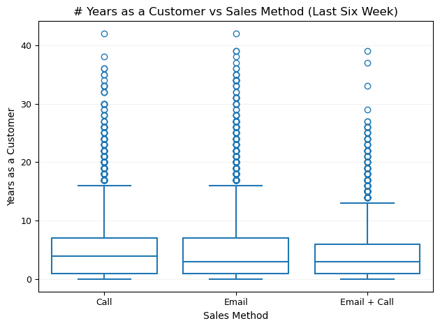

```python
#Investigate if the sales team contacted customers differently based on how long they've been a customer ('years_as_customer')
display(df.groupby('sales_method')['years_as_customer'].describe())

#Make a plot
ax1 = sns.boxplot(data=df, x='sales_method', y='years_as_customer', order=['Call','Email','Email + Call'], fill=False)
#edit plot details
plt.title('# Years as a Customer vs Sales Method (Last Six Week)')
plt.xlabel('Sales Method')
plt.xticks(fontsize=9)
plt.ylabel('Years as a Customer')
plt.yticks(fontsize=9)
plt.grid(axis='y',alpha=0.1,color='gray')
plt.tight_layout();
```

The figure above illustrates the distribution of years that customers have made purchases from *Pens & Printers* based on the sales method used to contact them in the past six weeks. Recall that *Pens & Printers* was founded in 1984, so a customer could have been making purchases from the company for 42 years at most.

Generally, these distributions across the three sales methods appear to be quite similar. If anything, the sales team tended to use both communication techniques ("Email + Call") for slightly less established customers (smaller 'years_as_customer' value), whereas they relied slightly more on one or the other methods ("Call" or "Email") for more established customers (larger 'years_as_customer' value). However, this difference between the three groups is very slight (no more than one year), so it is difficult to make any meaningful conclusions.

In summary, there is no meaningful relationship between these two variables. In other words, the sales team has generally utilized the three sales strategies equitably regardless of how long a customer has been buying from the company.

Next, the number of total products purchased by customers was investigated according to the sales method in which they were contacted.

| sales_method | count | mean | std | min | 25% | 50% | 75% | max |
| --- | --- | --- | --- | --- | --- | --- | --- | --- |
| Call | 4962.0 | 9.509674 | 1.733856 | 7.0 | 8.0 | 10.0 | 11.0 | 14.0 |
| Email | 7466.0 | 9.729306 | 1.179299 | 8.0 | 9.0 | 10.0 | 11.0 | 15.0 |
| Email + Call | 2572.0 | 12.225505 | 1.931459 | 8.0 | 10.0 | 12.0 | 13.0 | 16.0 |

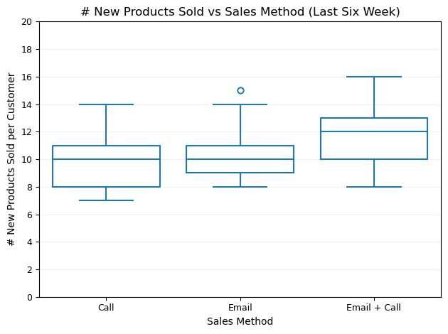

```python
#Investigate the # new products sold ('nb_sold') across 'sales_method's
display(df.groupby('sales_method')['nb_sold'].describe())

#Make a plot
ax1 = sns.boxplot(data=df, x='sales_method', y='nb_sold', order=['Call','Email','Email + Call'], fill=False)
#edit plot details
plt.title('# New Products Sold vs Sales Method (Last Six Week)')
plt.xlabel('Sales Method')
plt.xticks(fontsize=9)
plt.ylabel('# New Products Sold per Customer')
plt.yticks(ticks=range(0,21,2), fontsize=9)
plt.grid(axis='y',alpha=0.1,color='gray')
plt.tight_layout();
```

The visualization above displays the distributions of the number of new products purchased per customer according to the sales method utilized to contact them. This data spans the last six weeks.

There does appear to be a noticeable difference in the typical number of products bought by a customer depending on how they were contacted. More specifically, those who were reached out to via email & phone typically bought two more products (in quantity) than a customer who was contacted via email or phone only. Given the size of this difference within this relatively small range of values, it is meaningful.

- For context, customers bought somewhere between seven & 16 items over the last six weeks.

As such, there is a meaningful difference between the sales methods & the number of products customers typically bought.

Finally, the state in which customers resided were evaluated to check if there was any geographical trend in the sales data. For example, did the sales team prioritize customers from certain states or regions of the country?  
Note that the differences in populations of US states will naturally cause these numbers to differ. If patterns between these variables are present, then they could appear as considerable differences what states are most or least common. In this section, the five most & least common states were obtained for each sales method & compared to one another to check if the states were common or not, & if they were in a similar order.

```python
#Check if most/least common states differ across 'sales_method's
num_SM_state = df.groupby(['sales_method','state'])['customer_id'].count().reset_index().rename(
    columns={'customer_id':'#'})

#Most common states
#display(num_SM_state[num_SM_state.sales_method == 'Call'].sort_values('#', ascending=False).head(5))
#display(num_SM_state[num_SM_state.sales_method == 'Email'].sort_values('#', ascending=False).head(5))
#display(num_SM_state[num_SM_state.sales_method == 'Email + Call'].sort_values('#', ascending=False).head(5))

#Least common states
display(num_SM_state[num_SM_state.sales_method == 'Call'].sort_values('#', ascending=True).head(5))
display(num_SM_state[num_SM_state.sales_method == 'Email'].sort_values('#', ascending=True).head(5))
display(num_SM_state[num_SM_state.sales_method == 'Email + Call'].sort_values('#', ascending=True).head(5))
```

|  | sales_method | state | # |
| --- | --- | --- | --- |
| 33 | Call | North Dakota | 7 |
| 44 | Call | Vermont | 9 |
| 7 | Call | Delaware | 9 |
| 40 | Call | South Dakota | 11 |
| 49 | Call | Wyoming | 12 |

|  | sales_method | state | # |
| --- | --- | --- | --- |
| 94 | Email | Vermont | 11 |
| 99 | Email | Wyoming | 15 |
| 83 | Email | North Dakota | 17 |
| 57 | Email | Delaware | 17 |
| 88 | Email | Rhode Island | 19 |

|  | sales_method | state | # |
| --- | --- | --- | --- |
| 125 | Email + Call | Montana | 4 |
| 128 | Email + Call | New Hampshire | 5 |
| 149 | Email + Call | Wyoming | 6 |
| 101 | Email + Call | Alaska | 6 |
| 133 | Email + Call | North Dakota | 6 |

As a result, it doesn't seem apparent that there is a clear trend between these variables. In other words, *Pens & Printers* has done a good job in equitably contacting & selling to customers across the US.

### Analysis V - Conclusions

Additional variables were analyzed according to the sales method utilized to contact customers including the number of years a customer has made purchases, the number of new products that they bought, & their state of residence. Of these three variables, only the number of products purchased appeared to have a meaningful relationship with the sales methods.

- More specifically, customers who were contacted via email *&* phone typically bought two more products (in quantity) than a customer who was contacted via email *or* phone.

### Sources

- [Markdown Guide](https://s3.amazonaws.com/talent-assets.datacamp.com/Markdown+Guide.pdf)